# R_시각화

Jang, Eunhee

2018년 5월 15일

## 그래프의 종류

1. 막대그래프
2. 원형그래프
3. 산포도/라인(PLOT)그래프
4. 지도그래프
5. 소리를 시각화
6. 구글에서 제공하는 그래프
7. 워드 클라우드
8. 사분위수 그래프

### 데이터에 맞는 그래프를 선택하려면?

1. 막대그래프 : 데이터의 크기의 차이를 섬세하게 확인

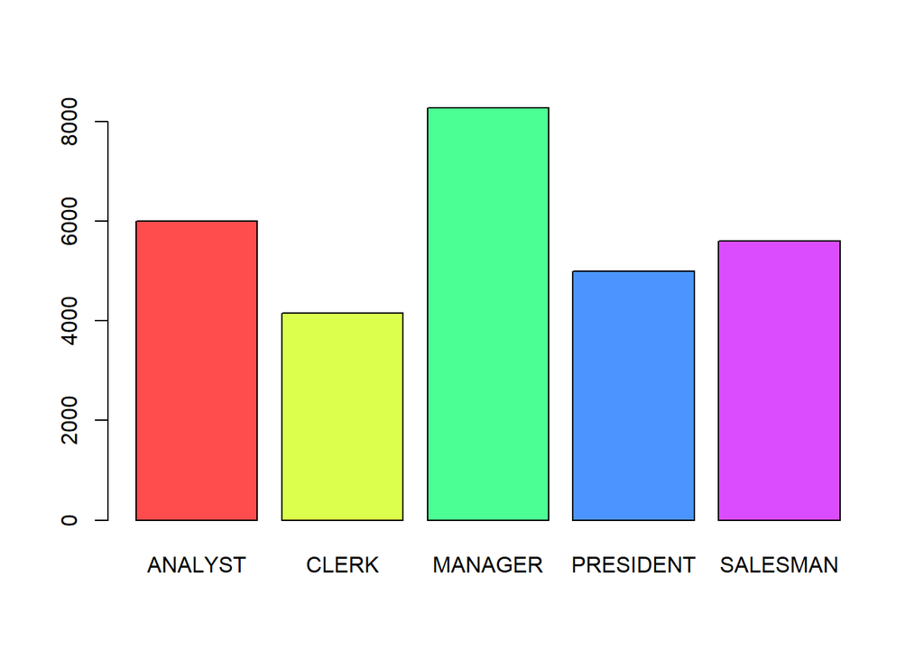

```r
    emp <- read.csv("C:/data/emp.csv")
    x <- tapply(emp$sal, emp$job, sum)

    lable <- round(x/sum(x)*100,1)
    lable2 <- paste(names(x), lable, '%')

    barplot(x, col = rainbow(5, alpha = 0.7))
```

2. 원형그래프 : 데이터간의 비율 확인(but, 디테일하지 않을 수 있음)

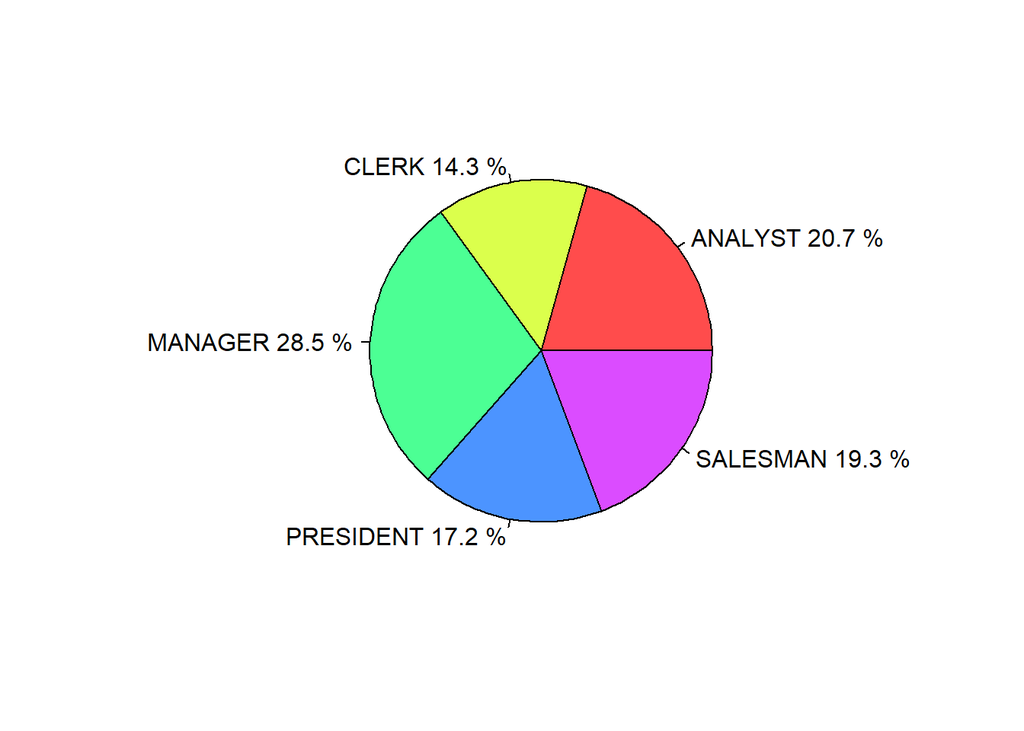

```r
    x <- tapply(emp$sal, emp$job, sum)

    lable <- round(x/sum(x)*100,1)
    lable2 <- paste(names(x), lable, '%')

    pie(x, col = rainbow(5, alpha = 0.7), labels = lable2)
```

3. 라인(PLOT)그래프 : 시간의 흐름에 따른 데이터의 변화를 확인할 때 데이터의 상관관계를 확인할 때

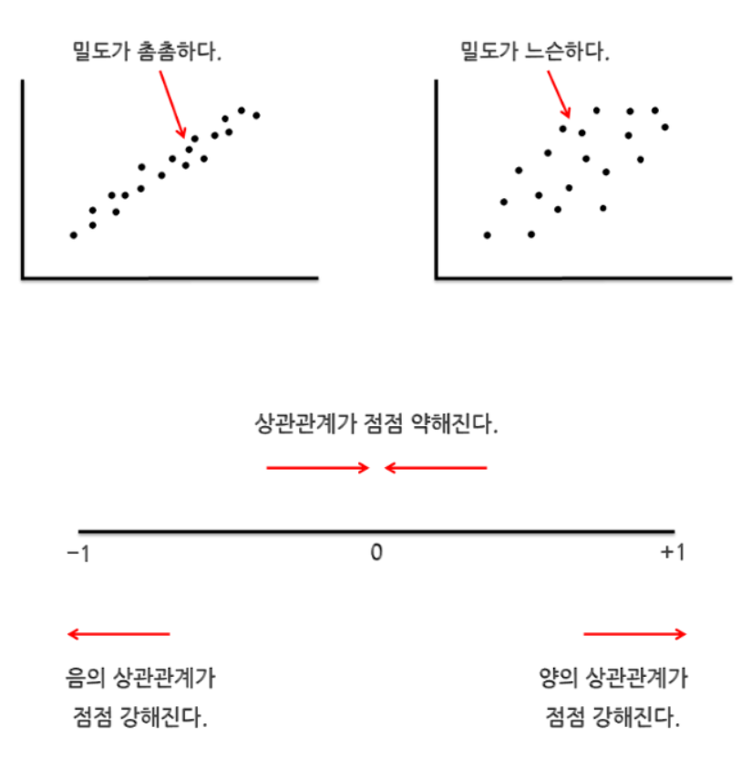

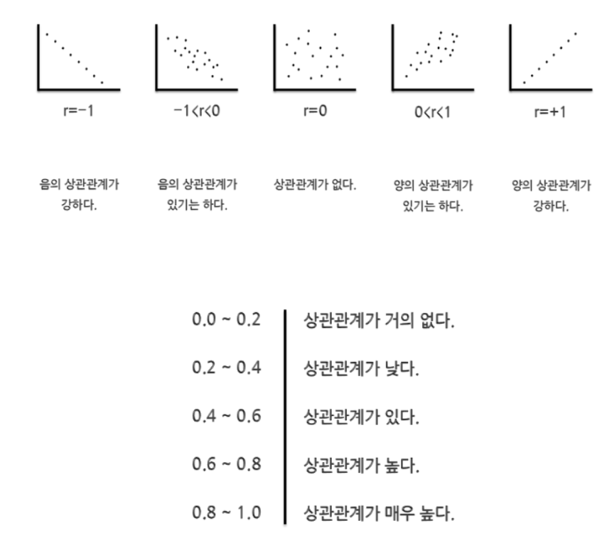

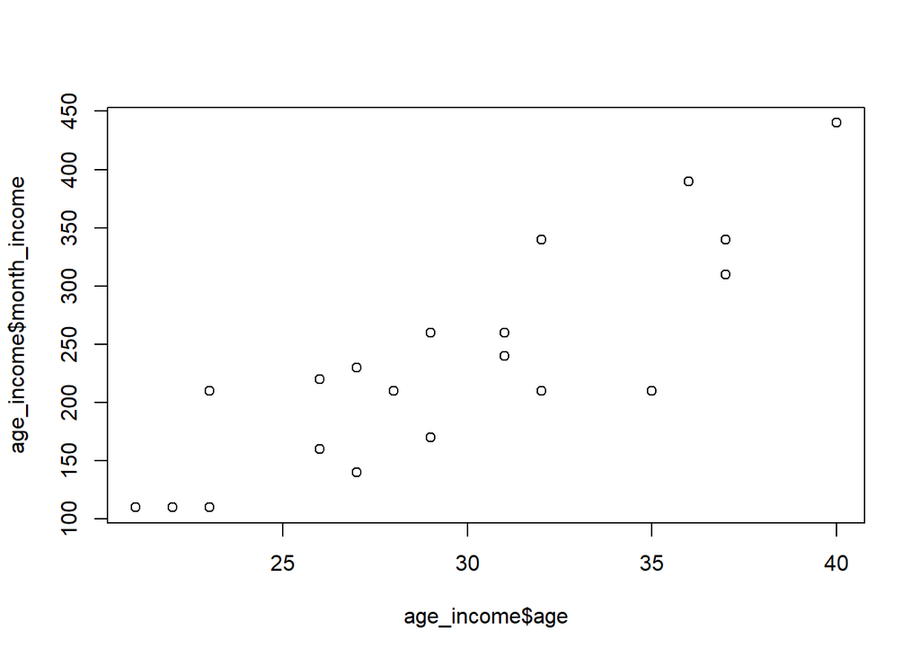

```r
    age_income <- read.csv("C:/data/age_income.csv")

    plot(age_income$age, age_income$month_income)
```

### 막대 그래프

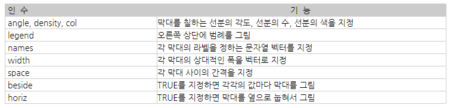

#### 문제 106. emp 테이블의 월급으로 기본적인 막대그래프를 그리시오

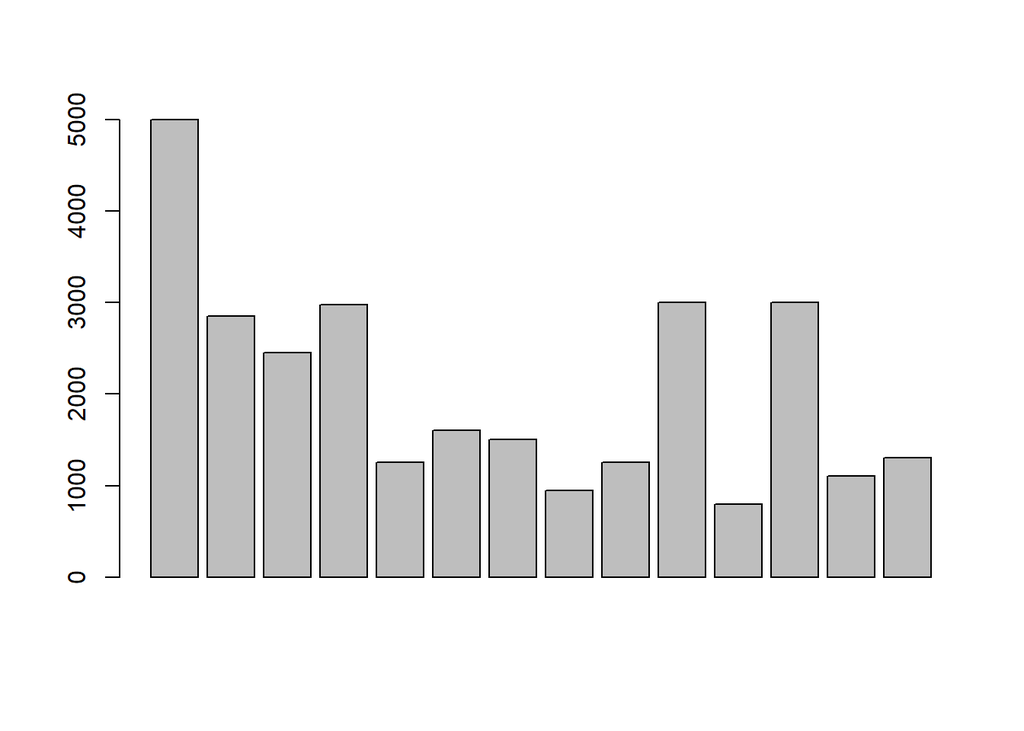

```r
emp <- read.csv("C:/data/emp.csv", header = T)
attach(emp)
  barplot(emp$sal)
```

#### 문제 107. 문제 106번 그래프에 제목을 Salary Bar Chart라고 이름을 붙이시오

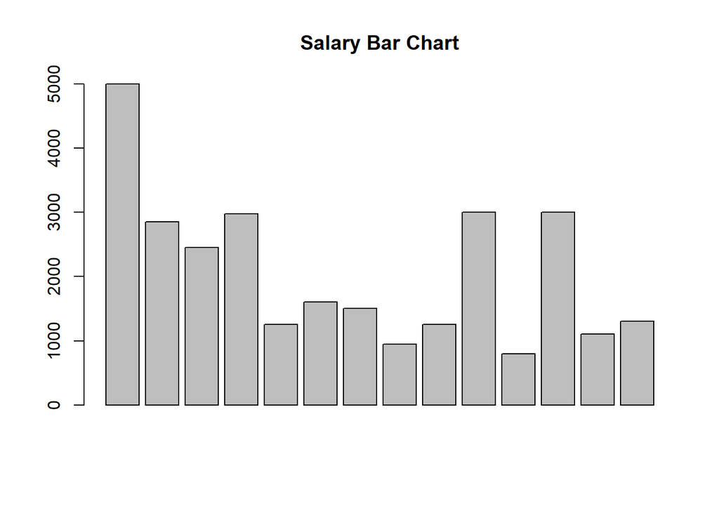

```r
barplot(emp$sal,main="Salary Bar Chart")
```

#### 문제 108. 문제 107번의 막대 그래프 X 축에 사원이름을 출력하시오

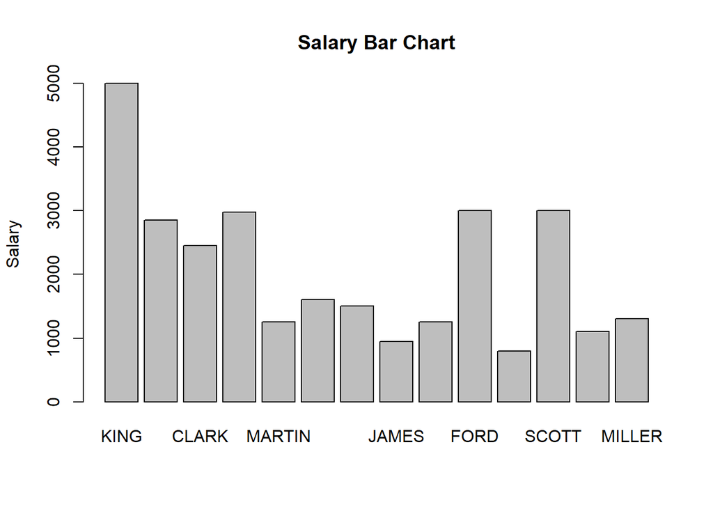

```r
barplot(emp$sal,main="Salary Bar Chart",names.arg = emp$ename,ylab="Salary")
```

#### 문제 109. x축 글씨 크기 조정

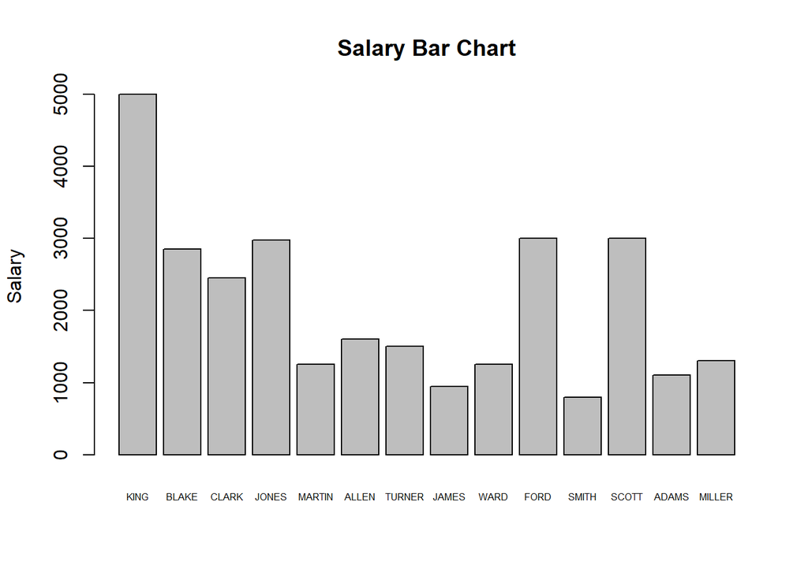

```r
barplot(emp$sal,main="Salary Bar Chart",names.arg = emp$ename,ylab="Salary",cex.names = 0.5)
```

```r
# x축 글씨 크키조정
```

#### 문제 110. bar에 컬러주기

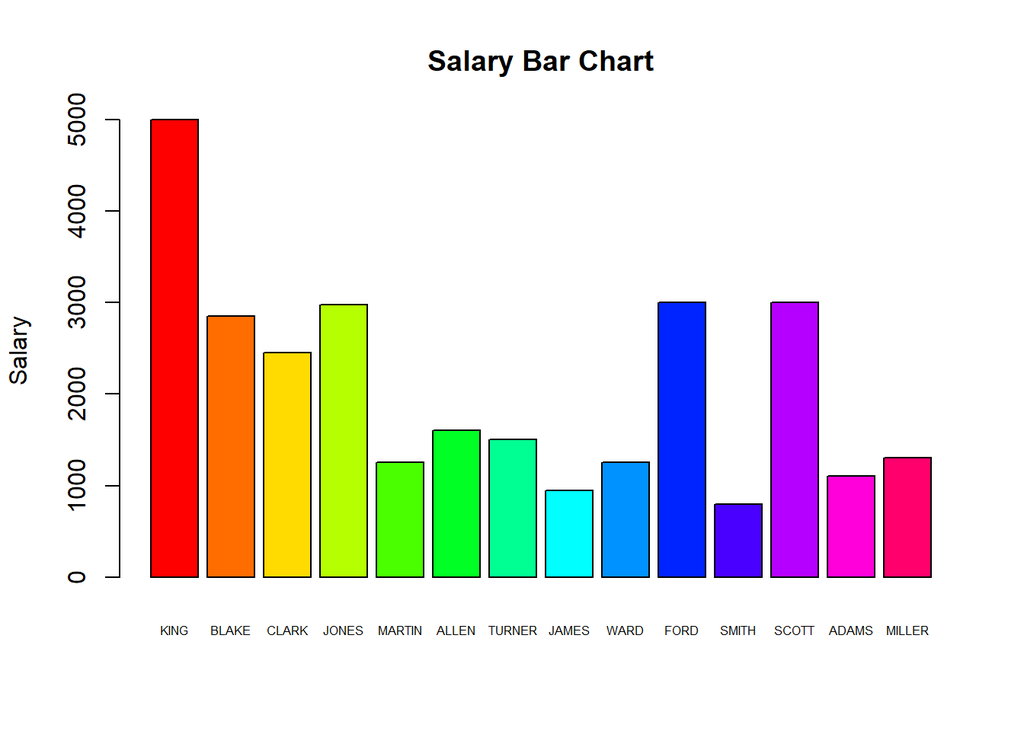

```r
barplot(emp$sal,main="Salary Bar Chart",names.arg = emp$ename, ylab="Salary",cex.names = 0.5, col = rainbow(14))
```

#### 문제111. 치킨집 년도별 창업건수를 막대 그래프로 시각화 하시오

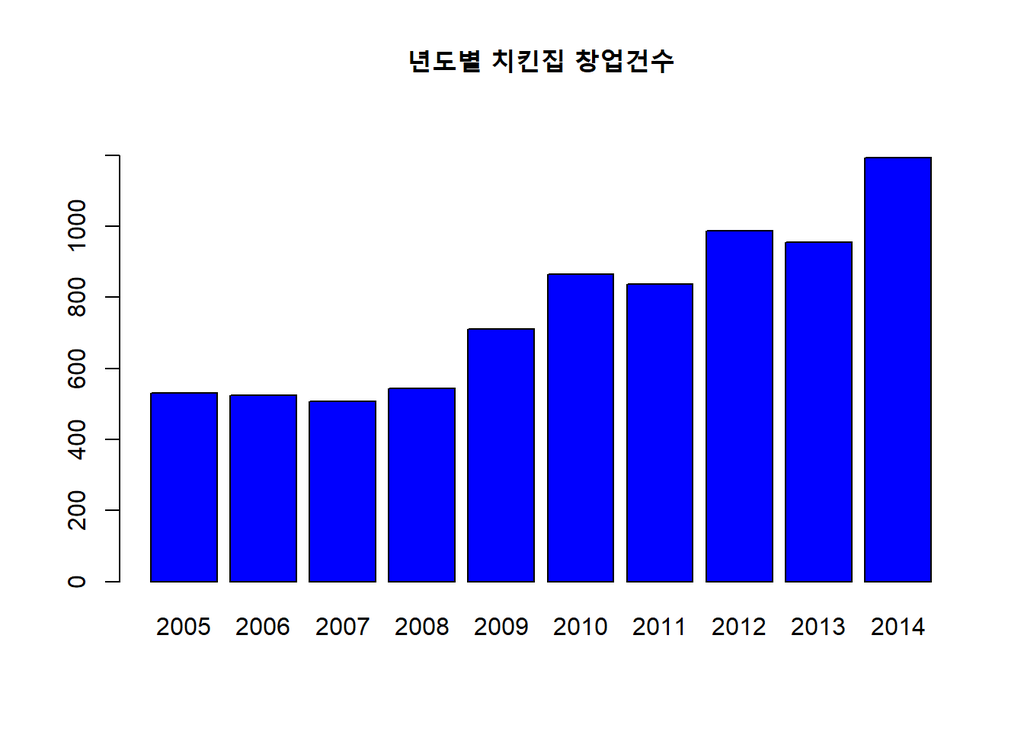

```r
create_cnt  <- read.csv("C:/data/창업건수.csv", header=T)

barplot(create_cnt$치킨, main = "년도별 치킨집 창업건수", names.arg=create_cnt$X,col = ("blue"),ylim = c(0,1300))
```

#### 문제112. 치킨집 년도별 폐업건수를 막대 그래프로 시각화 하시오.

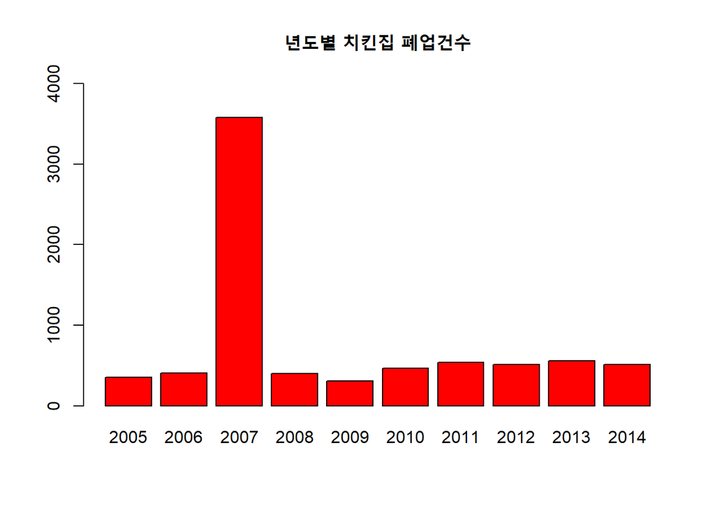

```r
drop_cnt <- read.csv("C:/data/폐업건수.csv",header=T)

barplot(drop_cnt$치킨, main = "년도별 치킨집 폐업건수", names.arg=drop_cnt$X,col = ("red"),ylim = c(0,4000))
```

```r
#graphics.off()
```

#### 문제113. 치킨집 년도별 창업건수와 폐업건수를 같이 막대 그래프로 그리는데 같이 출력되게 하시오

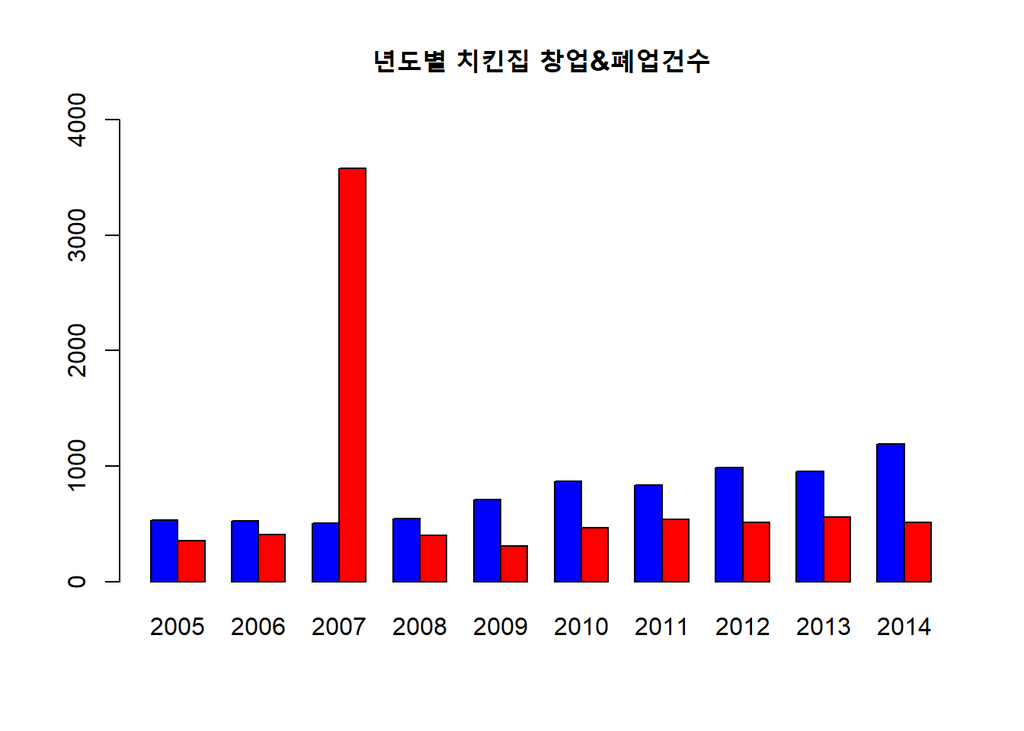

```r
x <- rbind(create_cnt$치킨집, drop_cnt$치킨집)
barplot(x, main = "년도별 치킨집 창업&폐업건수", names.arg = create_cnt$X, col = c("blue", "red"),
        ylim = c(0, 4000), beside = T)
```

#### 문제114. 문제113번에 legend를 달아서 파란색이 창업이고 빨간색이 폐업이다라고 하시오

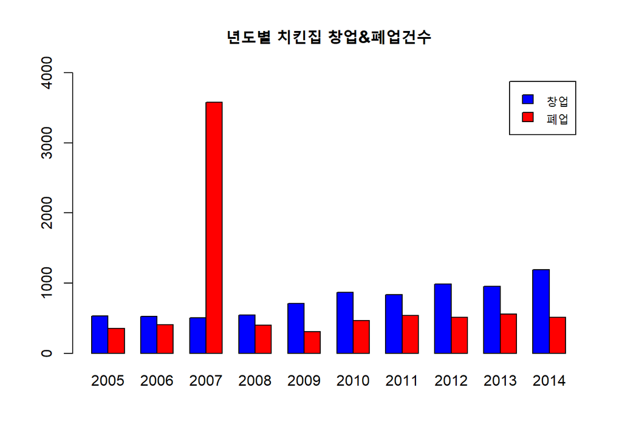

```r
x <- rbind(create_cnt$치킨집, drop_cnt$치킨집)
#rbind: 조인과 같은..
barplot(x, main = "년도별 치킨집 창업&폐업건수", names.arg = create_cnt$X, col = c("blue", "red"),
        ylim = c(0, 4000), beside = T, legend = c("창업","폐업"))
```

```r
# 조류독감: 2006년 11월 22일부터 2007년 3월 6일까지 104일간 5개 시군에서 7건이 발생하여 가금류 280만마리를 살처분하고, 살처분보상금 등 582억원의 예산이 투입되었다.
```

#### 문제115. 카페가 얼마나 창업을 하고 얼마나 폐업을 하는지 막대 그래프로 시각화 하시오.

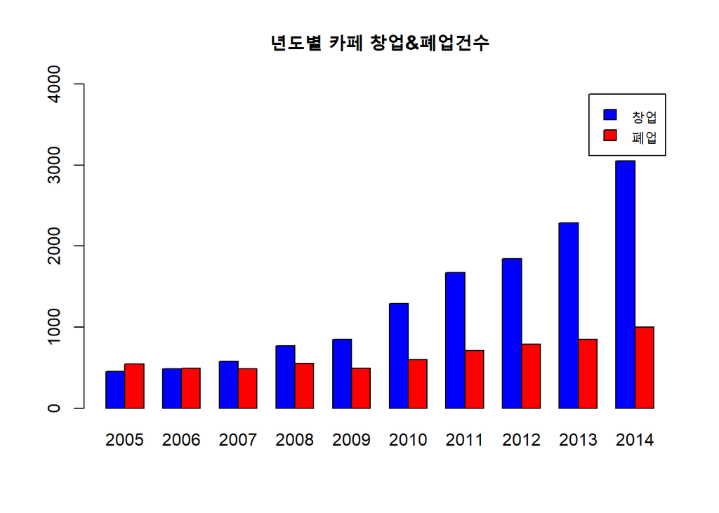

```r
y <- rbind(create_cnt$커피음료, drop_cnt$커피음료)
barplot(y, main = "년도별 카페 창업&폐업건수", names.arg = create_cnt$X, col = c("blue", "red"),
          ylim = c(0, 4000), beside = T, legend = c("창업", "폐업"))
```

### 원형(pie)그래프

비율을 나타낼 때 좋다.

#### 문제116. 사원 테이블의 월급으로 원형 그래프를 그리시오

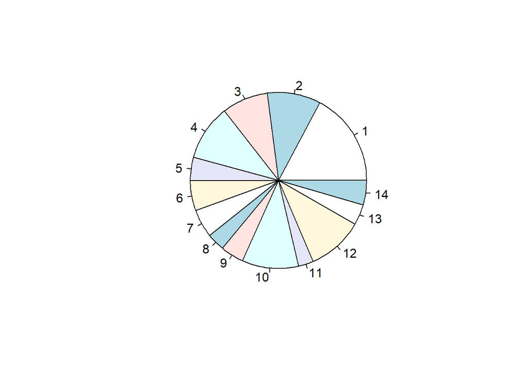

```r
pie(emp$sal)
```

#### 문제117. 문제116을 다시 수정하는데 색깔을 좀더 화려하게 시각화 하시오

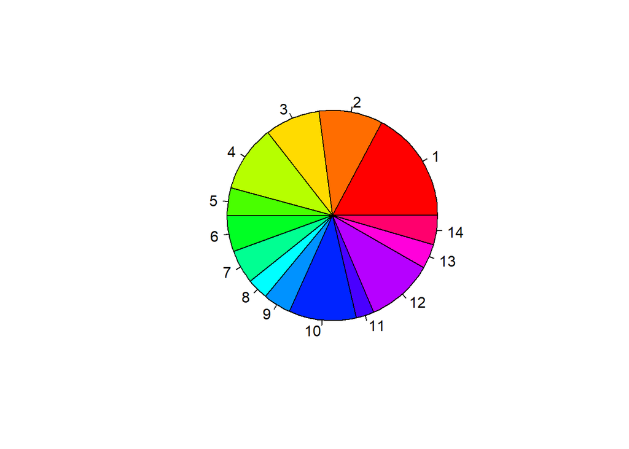

```r
pie(emp$sal, col = rainbow(14))
```

#### 문제118. 문제 117번을 다시 수행하는데 제목을 Salary Pie Chart라고 붙이시오

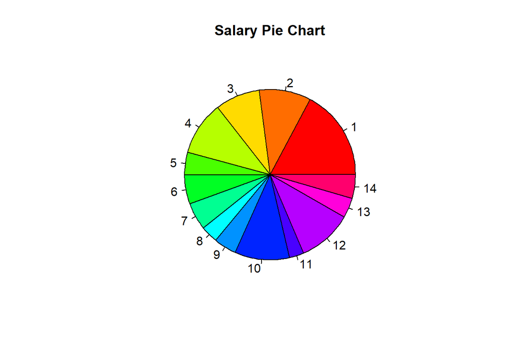

```r
pie(emp$sal, col= rainbow(14), main = "Salary Pie Chart")
```

#### 문제119. 문제118번을 다시수행하는데 누구의 월급인지 이름을 붙이시오

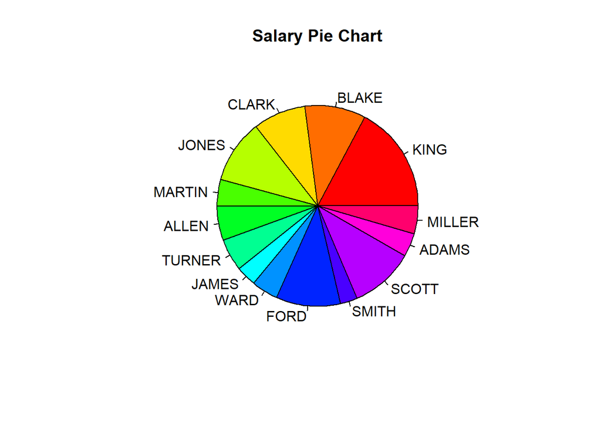

```r
pie(emp$sal, col= rainbow(14), main = "Salary Pie Chart", labels = emp$ename)
```

#### 문제120. 문제 119번 그래프에 월급의 비율을 붙여서 출력하시오

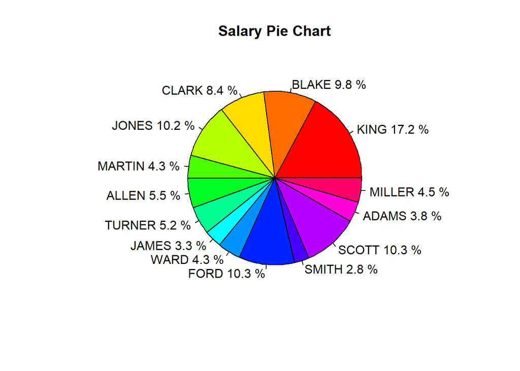

```r
rate <- round(emp$sal/sum(emp$sal) * 100, 1)
pie(emp$sal, col= rainbow(14), main = "Salary Pie Chart", labels = paste(emp$ename, rate,'%'))
```

#### 문제121. 2014년도 업종별 창업비율을 원형 그래프로 그리시오

```r
y <- create_cnt[create_cnt$X == 2014, (2:8)]
y
```

```
##    미용실 양식집 일식집 치킨집 커피음료 한식음식점 호프간이주점
## 10   1980   1870   1095   1193     3053       9772         1272
```

```r
z <- colnames(y)
z
```

```
## [1] "미용실"       "양식집"       "일식집"       "치킨집"
## [5] "커피음료"     "한식음식점"   "호프간이주점"
```

```r
rate <- round(y/sum(y)* 100, 1)
t(y)
```

```
##                10
## 미용실       1980
## 양식집       1870
## 일식집       1095
## 치킨집       1193
## 커피음료     3053
## 한식음식점   9772
## 호프간이주점 1272
```

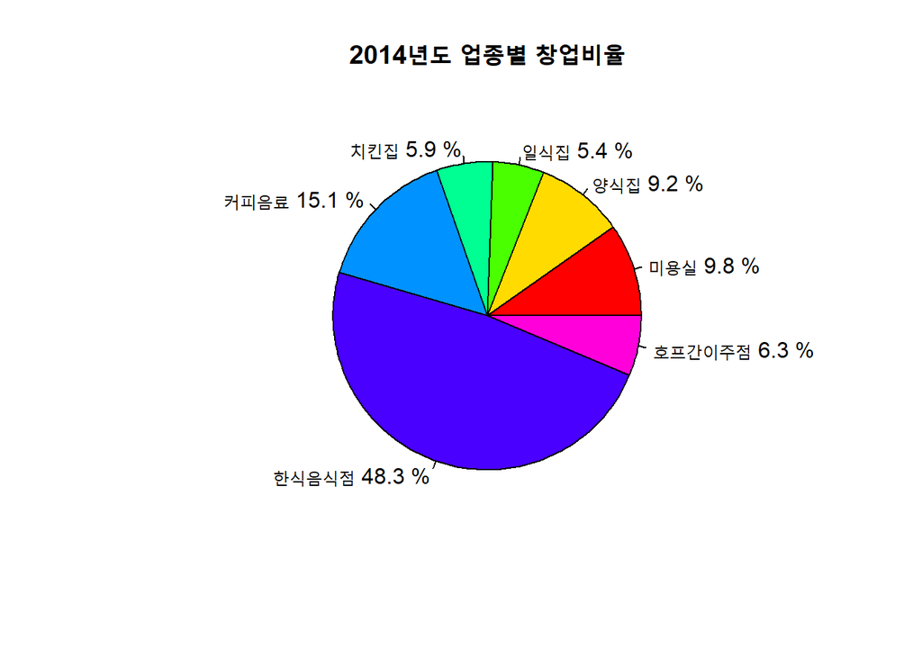

```r
# t(y)는 transfer로 행과 열을 바꿔줌
pie(t(y), col = rainbow(7), main = "2014년도 업종별 창업비율", labels = paste(z, rate, '%'))
```

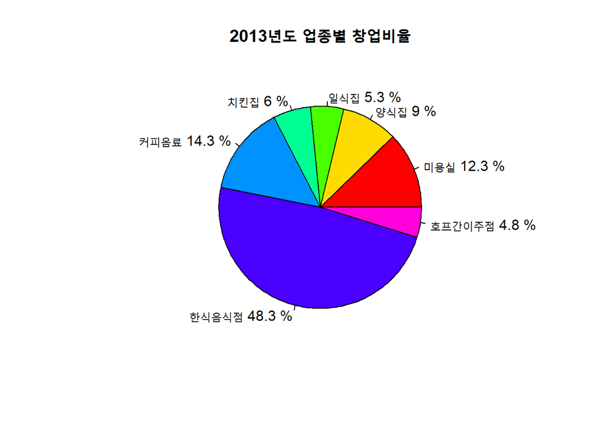

```r
create_cnt  <- read.csv("C:/data/창업건수.csv", header=T)
x <- create_cnt[create_cnt == 2013, (2:8)]

y <- colnames(x)

rate <- round(x/sum(x)*100, 1)

pie(t(x), col = rainbow(7), main = "2013년도 업종별 창업비율", labels = paste(y,rate,'%'))
```

#### 문제123. 문제122번 코드를 가지고 함수를 생성하는데 아래와 같이 함수를 실행해서 년도 입력하면 해당 년도의 원형 그래프가 그려지게 하시오

함수명 : show_pie

```r
show_pie <- function(){
  create_cnt  <- read.csv("C:/data/창업건수.csv", header=T)
  graphics.off()
  response <- readline(prompt = "연도를 입력하세요~ ")

  x <- create_cnt[create_cnt == response, (2:8)]

  rate <- round(x/sum(x)*100, 1)

  y <- paste(colnames(x),rate,'%')

  pie(t(x), col = rainbow(7), main = "2013년도 업종별 창업비율", labels = y)

}

# show_pie()
2013
```

```
## [1] 2013
```

#### 문제124. 문제123번을 다시 수행하는데 제목도 년도에 맞게 변경되게 하시오

```r
show_pie <- function(){

  graphics.off()
  response <- readline(prompt = '연도를 입력하세요~ ')

  x <- create_cnt[create_cnt == response, (2:8)]

  rate <- round(x/sum(x)*100, 1)

  y <- paste(colnames(x),rate,'%')

  pie(t(x), col = rainbow(7), main = paste(response,'년도 업종별 창업비율'), labels = y)

}


# show_pie()
2012
```

```
## [1] 2012
```

#### 문제125-126. 문제114번의 업종을 물어보게하고 업종을 입력하면 해당 업종의 창업, 폐업 현황이 막대그래프로 그려지는 함수를 생성하시오 + 그래프 이름도 변하도록

```r
show_bar <- function(){
  create_cnt  <- read.csv("C:/data/창업건수.csv", header=T)
  drop_cnt <- read.csv("C:/data/폐업건수.csv",header=T)

  graphics.off()
  response <- readline(prompt = '업종을 입력하세요~ ')
  x <- rbind(create_cnt[,response], drop_cnt[,response])
  #rbind: 조인과 같은..
  barplot(x, main = paste("년도별", response, '창업&폐업건수'), names.arg = create_cnt$X, col = c('blue', 'red'),
          ylim = c(0, 4000), beside = T, legend = c('창업','폐업'))
}


# show_bar()


# Error in barplot.default(x, main = paste("년도별", response, "창업&폐업건수")
#  'height' must be a vector or a matrix
```

#### 문제127. 아래의 스크립트를 수행하고 입력했을 때에값이 x7이라는 변수에 입력되게 하시오

```r
# menu(c("yes","no"), title = "Do you sant this?")
# x7 <- menu(c("yes","no"), title = "Do you sant this?")
# x7
```

#### 문제128. R의 menu함수를 이용해서 업종을 번호로 선택해서 막대 그래프가 출력되게 하시오

```r
show_bar <- function(){
  create_cnt  <- read.csv("C:/data/창업건수.csv", header=T)
  drop_cnt <- read.csv("C:/data/폐업건수.csv",header=T)

  graphics.off()
  response <- menu(c("x","미용실", "양식집", "일식집", "치킨집", "커피음료", "한식음식점", "호프간이주점"),
                   title = "Do you sant this?")
  x <- rbind(create_cnt[,response], drop_cnt[,response])

  barplot(x, main = paste("년도별",response,"창업&폐업건수"), names.arg = create_cnt$X, col = c("blue", "red"),
          ylim = c(0, 4000), beside = T, legend = c("창업","폐업"))

}


# show_bar()
```

#### 문제129. 문제128번에 타이틀을 업종명으로 바꾸시오.

```r
show_bar <- function(){
  create_cnt  <- read.csv("C:/data/창업건수.csv", header=T)
  drop_cnt <- read.csv("C:/data/폐업건수.csv",header=T)

  graphics.off()
  response <- menu(colnames(create_cnt), title = "Do you sant this?")
  x <- rbind(create_cnt[,response], drop_cnt[,response])

  barplot(x, main = paste("년도별", colnames(create_cnt[response]),"창업&폐업건수"), names.arg = create_cnt$X, col = c("blue", "red"), ylim = c(0, 4000), beside = T, legend = c("창업","폐업"))

}

# show_bar()
```

#### 문제130. 직업, 입사한 년도, 직업별 입사한 년도별 토탈월급을 출력하시오

```r
emp  <- read.csv("C:/data/emp.csv", header=T)
x2 <- tapply(emp$sal, list(emp$job, format(as.Date(emp$hiredate), '%Y')), sum)
x2[is.na(x2)] <- 0
x2
```

```
##           1980 1981 1982 1983
## ANALYST      0 3000 3000    0
## CLERK      800  950 1300 1100
## MANAGER      0 8275    0    0
## PRESIDENT    0 5000    0    0
## SALESMAN     0 5600    0    0
```

#### 문제131. colname과 rowname을 각각 출력하시오

```r
colnames(x2)
```

```
## [1] "1980" "1981" "1982" "1983"
```

```r
rownames(x2)
```

```
## [1] "ANALYST"   "CLERK"     "MANAGER"   "PRESIDENT" "SALESMAN"
```

#### 문제132. 데이터의 결과를 막대그래프로 시각화하시오

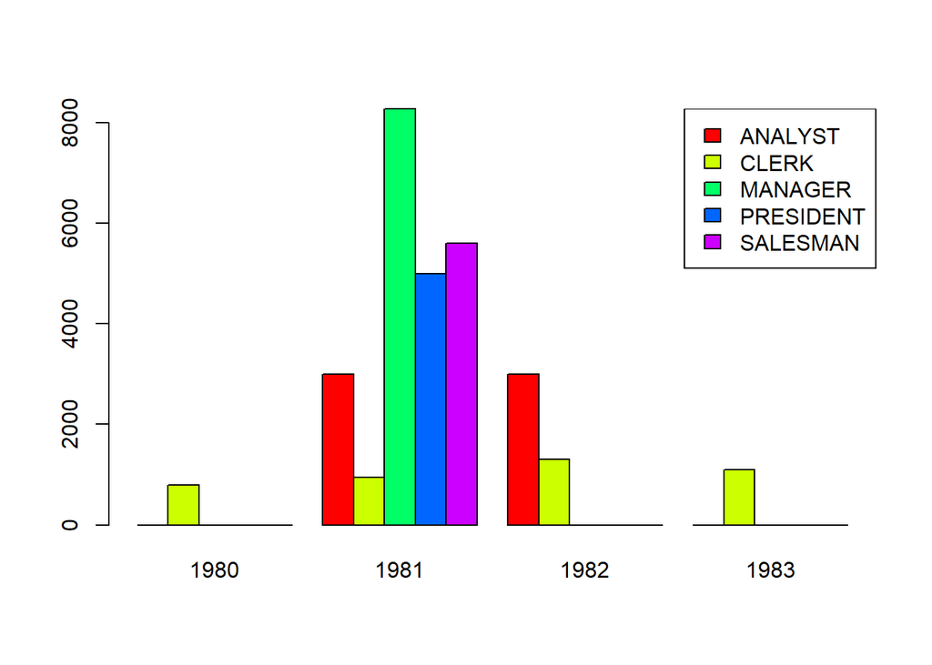

```r
#x11()
# 그래프의 창을 먼저 띄워놓는 방법

 barplot(x2, col = rainbow(5), beside = T)
  legend("topright", fill = rainbow(5), legend = rownames(x2))
```

#### 문제133.막대 그래프를 그릴 컬럼오(가로, 세로)을 물어보게하고 컬럼을 각각 입력하면 막대그래프가 그려지게 하시오

```r
show_emp_bar <- function(){

  emp  <- read.csv("C:/data/emp.csv", header=T)
  r_response <- readline(prompt = "가로가 될 컬럼명을 입력하세요~ ")
  c_response <- readline(prompt = "세로가 될 컬럼명을 입력하세요~ ")
  x2 <- tapply(emp$sal, emp[,c(c_response,r_response)], sum)
  #x2 <- tapply(emp$sal, list(emp[,c_response], emp[,r_response]), sum)
  x2[is.na(x2)] <- 0

  x2
  barplot(x2, col = rainbow(5), beside = T)
  legend("topright", fill = rainbow(5), legend = rownames(x2))
}


# show_emp_bar()
```

#### 문제134. 막대 그래프를 그릴 컬럼을 물어보게 하고 컬럼이 각각 입력하면 토탈월급에 대한 막대 그래프가 그려지게 하시오

```r
colnames(emp)
```

```
## [1] "empno"    "ename"    "job"      "mgr"      "hiredate" "sal"
## [7] "comm"     "deptno"   "grade"
```

```r
show_emp_bar <- function(){

  emp  <- read.csv("C:/data/emp.csv", header=T)

  r_response <- menu(colnames(emp), title = "가로?")
  c_response <- menu(colnames(emp), title = "세로?")

  x2 <- tapply(emp$sal, list(emp[,c_response], emp[,r_response]), sum)
  x2[is.na(x2)] <- 0

  x2
  barplot(x2, col = rainbow(5), beside = T)
  legend("topright", fill = rainbow(5), legend = rownames(x2))
}

# show_emp_bar()
```

```r
show_emp_bar <- function() {


  graphics.off()


  x1 <- menu( colnames(emp), title ='가로가 될 컬럼을 선택하세요 ~ ')

  x2 <- menu( colnames(emp), title ='세로가 될 컬럼을 선택하세요 ~ ')



  x1 <- colnames(emp)[x1]

  x2 <- colnames(emp)[x2]



  q <- tapply(emp$sal, list(emp[,x2], emp[,x1]), sum)

  q[is.na(q)] <- 0



  barplot(q,

          col = rainbow(nrow(q)),

          main = paste( x1, '별', x2, '의 월급총합' ),

          beside = T,

          ylim = c( 0, max(q)*1.5 ))



  legend("topright",

         rownames(q),

         title = x2 ,

         inset = 0,

         fill = rainbow(nrow(q)),

         cex=0.8)

}
```

#### 문제135_6. 직업과 직업별 토탈월급을 pie 그래프로 그리시오

```r
 x <- tapply(emp$sal, emp$job, sum)
 x
```

```
##   ANALYST     CLERK   MANAGER PRESIDENT  SALESMAN
##      6000      4150      8275      5000      5600
```

```r
 # 자동 ascending이 됨
 str(x)
```

```
##  int [1:5(1d)] 6000 4150 8275 5000 5600
##  - attr(*, "dimnames")=List of 1
##   ..$ : chr [1:5] "ANALYST" "CLERK" "MANAGER" "PRESIDENT" ...
```

```r
 rate <- round(x / sum(emp$sal) * 100,1)
 rate
```

```
##   ANALYST     CLERK   MANAGER PRESIDENT  SALESMAN
##      20.7      14.3      28.5      17.2      19.3
```

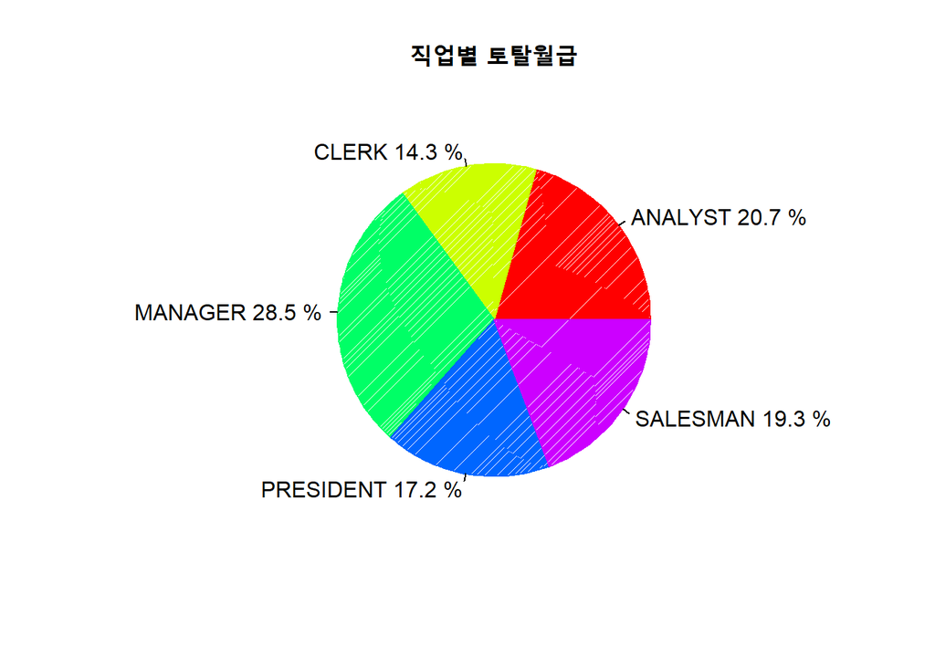

```r
 #pie(x, col = rainbow(5), main = paste(response,"직업별 토탈월급"), labels = paste(sort(unique(emp$job)),rate,'%'), density = 90)
 # sort의 이유를 모르겠...ㅎ
 # ascending을 위해 sort사용

 pie(x, col = rainbow(5), main = paste("직업별 토탈월급"), labels = paste(names(x),rate,'%'), density = 90)
```

#### 문제137. 문제136번의 그래프를 3D로 출력하시오

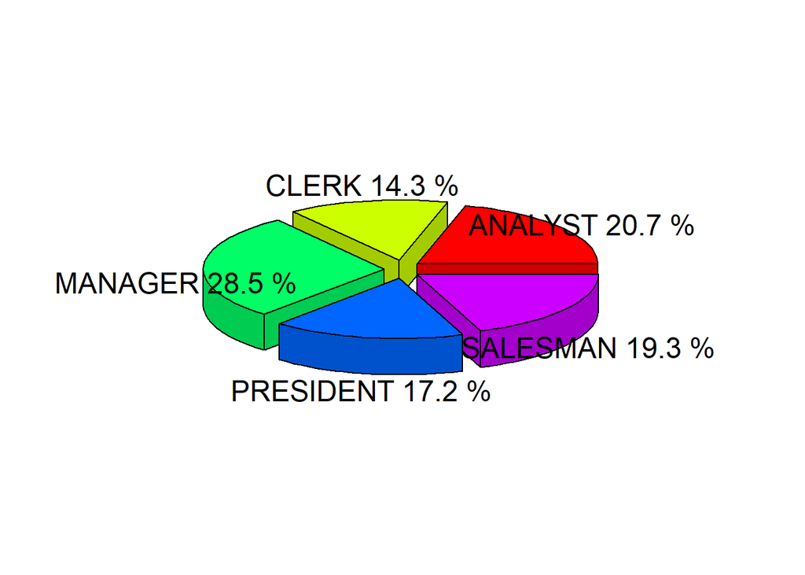

```r
# install.packages("plotrix")
library("plotrix")

pie3D(x,explode = 0.1, labels= paste(sort(unique(emp$job)),rate,'%'))
```

```r
#density = 90이 안됨
```

#### 문제138. switch문을 구현해보시오

```r
func <- function() {

  x1 <- menu( c("막대그래프", "원형그래프") , title ='원하는 그래프에 숫자를 선택하세요 ')

  switch(x1,
        barchart={
          # case 'foo' here...
          barplot(emp$sal,main="Salary Bar Chart",names.arg = emp$ename, ylab="Salary",cex.names = 0.5, col = rainbow(14))
          #print('foo')
        },
        piechart={
          # case 'bar' here...
          rate <- round(emp$sal/sum(emp$sal) * 100, 1)
          pie(emp$sal, col= rainbow(14), main = "Salary Pie Chart", labels = paste(emp$ename, rate,'%'))
          #print('bar')
        },
        {
           print('default')
        }
        )
}


# func()
```

#### 문제139. 그래프를 그릴 컬럼을 물어보게하고, 그래프의 종류도 물어보게해서 그래프가 그려지는 함수를 생성하시오

```r
func <- function() {

  emp  <- read.csv("C:/data/emp.csv", header=T)

  x  <- menu( colnames(emp) , title ='sum할 컬럼명(number)을 입력하세요 ')
  x1 <- menu( colnames(emp) , title ='기준이될 컬럼명을 입력하세요 ')
  x2 <- menu( colnames(emp) , title ='그루핑할 컬럼을 입력하세요 ')
  x3 <- menu( c("막대그래프", "원형그래프") , title ='원하는 그래프를 선택하세요 ')


  switch(x3,
        barchart={

        y <- tapply(emp[, x], list(emp[,x2], emp[,x1]), sum)
        y[is.na(y)] <- 0

        barplot(y, col = rainbow(length(y)), beside = T)
        legend("topright", fill = rainbow(14), legend = rownames(y))

        },
        piechart={

          z <- tapply(emp[,x], emp[,x1], sum)

          rate <- round( z / sum(emp[,x]) * 100, 1)
          pie(z, col= rainbow(length(names(z))), main = "Salary Pie Chart", labels = paste(names(z), rate,'%'))

        }
  )

}


# func()
```

```r
func139 <- function(){

  graphics.off()

  tot_set    <- c('sal')

  tot_col    <- menu(c('sal'), title = '합산할 컬럼을 선택하세요.')

  tot_col    <- tot_set[tot_col] #sal만_이름가져오기


  group_set  <- c('job', 'deptno')

  group_col  <- menu(group_set, title = '그룹핑 할 컬럼을 선택하세요.')

  group_col  <- group_set[group_col] #job, deptno만_이름가져오기


  graph_set  <- c('막대그래프', '원형그래프')

  graph_type <- menu(graph_set, title = '그래프 종류를 선택하세요.')


  plot_data  <- tapply(emp[,tot_col], emp[,group_col], sum)


  switch(graph_type,

         barplot = {

                    barplot(plot_data,

                            main = paste('Total ',

                                         toupper(tot_col),

                                         'Bar Chart',

                                         'Grouped By',

                                          toupper(group_col)),

                            ylab = tot_col,

                            cex.names = .8,
                            # x축 이름 크기

                            ylim = c(0, max( plot_data ) * 1.3),
                            # y축 길이

                            col = c('Lavender Blush', 'Dark Orchid', 'Medium Purple', 'Plum'))

                    },

         piechart = {

                     label <- paste(rownames(plot_data),

                                     round(plot_data/sum(plot_data)*100, 1), '%')

                     pie(plot_data,

                          main = paste('Total ',

                                        toupper(tot_col),

                                        'Pie Chart',

                                        'Grouped By',

                                        toupper(group_col)),

                          col = rainbow(nrow(plot_data)),

                          labels = label)

                    }

         )

}

# func139()
```

#### 문제140. 오라클과 R을 연동하시오

<사전작업> 1. 오라클 서비스를 올린다.(컴퓨터관리/서비스) 2. 오라클 리스너의 상태를 확인한다.(lsnrctl status) 3. 리스너 통해서 오라클에 접속이 되는지 확인한다.(sqlplus scott2/tiger@orcl)

```r
# install.packages('DBI')
#
# install.packages('RJDBC')

library(RJDBC)
# Error: 패키지 ‘rJava’는 로드되어질 수 없습니다
# java설치
library(DBI)


driver <- JDBC('oracle.jdbc.driver.OracleDriver', 'C:/data/ojdbc6.jar')

oracle_db <- dbConnect(driver, 'jdbc:oracle:thin:@//127.0.0.1:1522/orcl', 'scott2', 'tiger')

emp_query <- 'select * from emp'

emp_data <- dbGetQuery(oracle_db, emp_query)

emp_data
```

```
##    EMPNO  ENAME       JOB  MGR            HIREDATE  SAL COMM DEPTNO
## 1   7839   KING PRESIDENT   NA 1981-11-17 00:00:00 5000   NA     10
## 2   7698  BLAKE   MANAGER 7839 1981-05-01 00:00:00 2850   NA     30
## 3   7782  CLARK   MANAGER 7839 1981-05-09 00:00:00 2450   NA     10
## 4   7566  JONES   MANAGER 7839 1981-04-01 00:00:00 2975   NA     20
## 5   7654 MARTIN  SALESMAN 7698 1981-09-10 00:00:00 1250 1400     30
## 6   7499  ALLEN  SALESMAN 7698 1981-02-11 00:00:00 1600  300     30
## 7   7844 TURNER  SALESMAN 7698 1981-08-21 00:00:00 1500    0     30
## 8   7900  JAMES     CLERK 7698 1981-12-11 00:00:00  950   NA     30
## 9   7521   WARD  SALESMAN 7698 1981-02-23 00:00:00 1250  500     30
## 10  7902   FORD   ANALYST 7566 1981-12-11 00:00:00 3000   NA     20
## 11  7369  SMITH     CLERK 7902 1980-12-09 00:00:00  800   NA     20
## 12  7788  SCOTT   ANALYST 7566 1982-12-22 00:00:00 3000   NA     20
## 13  7876  ADAMS     CLERK 7788 1983-01-15 00:00:00 1100   NA     20
## 14  7934 MILLER     CLERK 7782 1982-01-11 00:00:00 1300   NA     10
```

#### 문제141. emp2 테이블의 데이터를 emp2_data에 로드하고 통신사, 나이를 가지고 그래프를 그리시오

```r
library(RJDBC)
# Error: 패키지 ‘rJava’는 로드되어질 수 없습니다
# java설치
library(DBI)


driver <- JDBC('oracle.jdbc.driver.OracleDriver', 'C:/data/ojdbc6.jar')

oracle_db <- dbConnect(driver, 'jdbc:oracle:thin:@//127.0.0.1:1522/orcl', 'scott2', 'tiger')

emp2_query <- 'select * from emp2'

emp2_data <- dbGetQuery(oracle_db, emp2_query)

emp2_data
```

```
##    EMPNO  ENAME AGE               BIRTH                    MAJOR
## 1     10 김원섭  26 1994-02-08 00:00:00               컴퓨터공학
## 2     11 김광록  27 1992-12-16 00:00:00               경영정보학
## 3     20 유혜린  26 1993-04-22 00:00:00             기술융합공학
## 4      8 이유진  25 1994-12-06 00:00:00           시스템경영공학
## 5      1 윤진민  27 1992-07-15 00:00:00                   경제학
## 6      9 백광흠  26 1993-06-18 00:00:00               컴퓨터공학
## 7     12 장은희  24 1996-01-07 00:00:00               경영정보학
## 8      4 김영토  28 1991-10-13 00:00:00 도시계획학 및 응용통계학
## 9      2 송윤호  27 1992-05-25 00:00:00               문헌정보학
## 10    28 차호성  28 1991-07-01 00:00:00                   경제학
## 11    17 방승준  26 1993-12-13 00:00:00               컴퓨터공학
## 12    16 이한새  25 1994-01-19 00:00:00                   경영학
## 13    23 이근호  28 1991-04-24 00:00:00                   통계학
## 14    18 신영근  25 1994-02-03 00:00:00               컴퓨터공학
```

[output cut: 78 more lines]

```r
func_emp2 <- function() {

  emp2  <- emp2_data

  x  <- menu( colnames(emp2) , title ='sum할 컬럼명(number)을 입력하세요 ')
  x1 <- menu( colnames(emp2) , title ='기준이될 컬럼명을 입력하세요 ')
  x2 <- menu( colnames(emp2) , title ='그루핑할 컬럼을 입력하세요 ')
  x3 <- menu( c("막대그래프", "원형그래프") , title ='원하는 그래프를 선택하세요 ')


  switch(x3,
        barchart={

        y <- tapply(emp2[, x], list(emp2[,x2], emp2[,x1]), sum)
        y[is.na(y)] <- 0

        barplot(y, col = rainbow(length(y)), beside = T)
        legend("topright", fill = rainbow(14), legend = rownames(y))

        },
        piechart={

          z <- tapply(emp2[,x], emp2[,x1], sum)

          rate <- round( z / sum(emp2[,x]) * 100, 1)
          pie(z, col= rainbow(length(names(z))), main = "Salary Pie Chart", labels = paste(names(z), rate,'%'))

        }
  )

}


# func_emp2()
```

### 시각자료 확인하기

https://www.stat.auckland.ac.nz/~ihaka/courses/787/R-colours-a4.pdf